# Analysis of red wine by Dilin John

Load all of the packages that you end up using in your analysis in this code chunk.

Notice that the parameter “echo” was set to FALSE for this code chunk. This prevents the code from displaying in the knitted HTML output. You should set echo=FALSE for all code chunks in your file, unless it makes sense for your report to show the code that generated a particular plot.

The other parameters for “message” and “warning” should also be set to FALSE for other code chunks once you have verified that each plot comes out as you want it to. This will clean up the flow of your report.

Load the Data Explore dimensions and variables

```r
redwine <- read.csv('wineQualityReds.csv')
dim(redwine)
```

```
## [1] 1599   13
```

```r
names(redwine)
```

```
##  [1] "X"                    "fixed.acidity"        "volatile.acidity"
##  [4] "citric.acid"          "residual.sugar"       "chlorides"
##  [7] "free.sulfur.dioxide"  "total.sulfur.dioxide" "density"
## [10] "pH"                   "sulphates"            "alcohol"
## [13] "quality"
```

```r
range(redwine$X)
```

```
## [1]    1 1599
```

X is nothign but a counter from 1 -1599 - which is the sample size

Before plotting,it would be good to look for any outliers in the features, for which standard deviation will be used

The usual way to determine outliers is calculating an upper and lower fence with the Inter Quartile Range (IQR). This is done as following:

Reference: https://stats.stackexchange.com/questions/175999/determine-outliers-using-iqr-or-standard-deviation

- First Quartile = Q1
- Third Quartile = Q3
- IQR = Q3 - Q1

Multiplier: This is usually a factor of 1.5 for normal outliers, or 3.0 for extreme outliers. The multiplier would be determined by trial and error.

Lower fence = Q1 - (IQR * multiplier) Upper fence = Q3 + (IQR * multiplier)

Calculating boundaries using standard deviation would be done as following:

Lower fence = Mean - (Standard deviation * multiplier) Upper fence = Mean + (Standard deviation * multiplier)

Here we will use a multiplier of 3.5

- Defining functions

Finding the standard deviation and outlier line for the feature to be examined

```r
sd_and_outlier <- function(feature) {
  stdev = sd(feature)
  outlier = stdev*3.5 + median(feature)
  print(paste('standard deviation =', round(stdev, 3)))
  print(paste('outlier are greater than: ', round(outlier, 3)))
}
```

Finding the higher outlier line

```r
high_outlier_line <- function(feature){
  p1 = geom_hline(yintercept = (median(feature) + 3.5*sd(feature)), alpha =0.5, linetype = 2)
  return(p1)
}
```

```r
low_outlier_line <- function(feature){
  p1 <- geom_hline(yintercept = (median(feature) + sd(feature) *3.5), alpha = 0.5, color = 'blue', linetype = 2)
  return(p1)
}
```

```r
box_hist_plot <- function(feature, feature_name){
  p1 <- ggplot(aes(x= 1, y= feature), data = redwine)+
              geom_jitter(alpha =0.1)+
              geom_boxplot(alpha = 0.2, color = 'red')+
              stat_summary(fun.y = mean,color = 'red', shape =1, geom = 'point')+
              high_outlier_line(feature)+
              low_outlier_line(feature)+
              ylab(feature_name)

  p2 <- ggplot(aes(feature), data = redwine)+
            geom_histogram(bins = 30)+
            labs(x = feature_name)

  p3 <- grid.arrange(p1, p2, ncol= 2)
  return(p3)
}
```

Same plot with the feature transformed by log10 with the high and low outliers, incase distribution is skewed or bimodal - applying appropriate transformations

```r
box_hist_log10_plot <- function(feature, feature_name){
  p1 <- ggplot(aes(x=1, y= log10(feature)), data = redwine)+
              geom_jitter(alpha =0.1)+
              geom_boxplot(alpha = 0.2, color = 'red')+
              stat_summary(fun.y = mean,color = 'red', shape =1, geom = 'point')+
              high_outlier_line(log10(feature))+
              low_outlier_line(feature)+
              ylab(feature_name)

  p2 <- ggplot(aes(log10(feature)), data = redwine)+
            geom_histogram(bins = 30)+
            labs(x = feature_name)

  p3 <- grid.arrange(p1, p2, ncol= 2)
  return(p3)
}
```

Since the focus will be on understanding the quality of wine, the ‘quality’ variable will be # # factored and a box plot and a scatter plot will be joined on the same graph

```r
box_scatter <- function(feature, feature_name){
  p1 <- ggplot(aes(x = factor(quality), y = feature), data = redwine)+
    geom_jitter(alpha=0.4)+
    geom_boxplot(alpha = 0.5, color ='blue')+
    stat_summary(fun.y = median,
                 geom = 'point',
                 color = 'red',
                 shape = 8,
                 size = 4
                 )+
    geom_smooth(aes(quality-2, feature),
                method = lm,
                se = FALSE,
                size = 1,
                color = 'green')+
    high_outlier_line(feature)+
    low_outlier_line(feature)+
    ylab(feature_name)

  return(p1)
}
```

transforming the feature to log10 scale, similar to the box_scatter

```r
box_scatter_log10 <- function(feature, feature_name) {
  p1 <- ggplot(aes(x = factor(quality), y = log10(feature)), data = redwine)+
    geom_jitter(alpha=0.4)+
    geom_boxplot(alpha = 0.5, color ='blue')+
    stat_summary(fun.y = median,
                 geom = 'point',
                 color = 'red',
                 shape = 8,
                 size = 4
                 )+
    geom_smooth(aes(quality-2, feature),
                method = lm,
                se = FALSE,
                size = 1,
                color = 'green')+
    high_outlier_line(feature)+
    ylab(feature_name)

  return(p1)
}
```

A plot similar to the ‘box_scatter’ except the plot is limited by using the ylim_lower and ylim_upper using coord_cartesian to remove percentiles for a better view

```r
box_scatter_ylim <- function(feature, feature_name,ylim_lower, ylim_upper ){
  p1 <- ggplot(aes(x = factor(quality), y = feature), data = redwine)+
    geom_jitter(alpha=0.4)+
    geom_boxplot(alpha = 0.5, color ='blue')+
    stat_summary(fun.y = median,
                 geom = 'point',
                 color = 'red',
                 shape = 16,
                 size = 4
                 )+
    geom_smooth(aes(quality-2, feature),
                method = lm,
                se = FALSE,
                size = 1,
                color = 'green')+
    coord_cartesian(ylim = c(quantile(feature, ylim_lower), quantile(feature, ylim_upper)))+
    ylab(feature_name)

  return(p1)
}
```

Summary statistics of a feature with respec to the ‘quality’ variable of wine, since I am trying to find what features influence wine quality

```r
stat_by_quality <- function(feature) {
  by(feature, redwine$quality, summary)
}
```

For the multi scatter plots, which involves one or more features to be examined as factor of ‘quality’ variable

```r
multi_scatter <- function(feature1, feature1_name, feature2, feature2_name) {
  p1 <- ggplot(aes(feature1, feature2, color = factor(quality)), data = redwine)+
    geom_jitter(alpha = 0.5)+
    scale_color_brewer(type = 'seq', direction= -1,
                       palette = 'Set1',
                       guide = guide_legend(title = 'Quality'))+
    geom_smooth(method ='lm', se= FALSE, size=1)+
    xlab(feature1_name)+
    ylab(feature2_name)+
    theme(panel.background = element_rect(fill = 'ivory3'))

  return(p1)
}
```

### Testing

box_scatter(redwine$fixed.acidity, 'fixed acidity') box_hist_plot(redwine$fixed.acidity, ‘fixed acidity’) box_scatter(redwine$residual.sugar, "residual sugar") box_scatter_log10(redwine$residual.sugar, “residual sugar”) box_scatter_ylim(redwine$residual.sugar, "residual sugar", 0, 0.98) stat_by_quality(redwine$residual.sugar) multi_scatter(redwine$alcohol, "alcohol", redwine$volatile.acidity, “volatile acidity”)

The dataset that will be explored is the wine Quality dataset for redwines, which has 1599 observations with 13 variables. My intention to explore this dataset is to identify what is a good wine based on the variables provided and how they are correlated. The primary focus will be on the ‘quality’ of the wine.**

## Univariate Plots Section

This dataset has 1599 observations and 13 variables and i would like to find which fo these variables affect the quality of wine**

```r
dim(redwine)
```

```
## [1] 1599   13
```

```r
summary(redwine)
```

```
##        X          fixed.acidity   volatile.acidity  citric.acid
##  Min.   :   1.0   Min.   : 4.60   Min.   :0.1200   Min.   :0.000
##  1st Qu.: 400.5   1st Qu.: 7.10   1st Qu.:0.3900   1st Qu.:0.090
##  Median : 800.0   Median : 7.90   Median :0.5200   Median :0.260
##  Mean   : 800.0   Mean   : 8.32   Mean   :0.5278   Mean   :0.271
##  3rd Qu.:1199.5   3rd Qu.: 9.20   3rd Qu.:0.6400   3rd Qu.:0.420
##  Max.   :1599.0   Max.   :15.90   Max.   :1.5800   Max.   :1.000
##  residual.sugar     chlorides       free.sulfur.dioxide
##  Min.   : 0.900   Min.   :0.01200   Min.   : 1.00
##  1st Qu.: 1.900   1st Qu.:0.07000   1st Qu.: 7.00
##  Median : 2.200   Median :0.07900   Median :14.00
##  Mean   : 2.539   Mean   :0.08747   Mean   :15.87
##  3rd Qu.: 2.600   3rd Qu.:0.09000   3rd Qu.:21.00
##  Max.   :15.500   Max.   :0.61100   Max.   :72.00
##  total.sulfur.dioxide    density             pH          sulphates
##  Min.   :  6.00       Min.   :0.9901   Min.   :2.740   Min.   :0.3300
##  1st Qu.: 22.00       1st Qu.:0.9956   1st Qu.:3.210   1st Qu.:0.5500
##  Median : 38.00       Median :0.9968   Median :3.310   Median :0.6200
##  Mean   : 46.47       Mean   :0.9967   Mean   :3.311   Mean   :0.6581
##  3rd Qu.: 62.00       3rd Qu.:0.9978   3rd Qu.:3.400   3rd Qu.:0.7300
##  Max.   :289.00       Max.   :1.0037   Max.   :4.010   Max.   :2.0000
##     alcohol         quality
##  Min.   : 8.40   Min.   :3.000
##  1st Qu.: 9.50   1st Qu.:5.000
##  Median :10.20   Median :6.000
##  Mean   :10.42   Mean   :5.636
##  3rd Qu.:11.10   3rd Qu.:6.000
##  Max.   :14.90   Max.   :8.000
```

```r
str(redwine)
```

```
## 'data.frame':    1599 obs. of  13 variables:
##  $ X                   : int  1 2 3 4 5 6 7 8 9 10 ...
##  $ fixed.acidity       : num  7.4 7.8 7.8 11.2 7.4 7.4 7.9 7.3 7.8 7.5 ...
##  $ volatile.acidity    : num  0.7 0.88 0.76 0.28 0.7 0.66 0.6 0.65 0.58 0.5 ...
##  $ citric.acid         : num  0 0 0.04 0.56 0 0 0.06 0 0.02 0.36 ...
##  $ residual.sugar      : num  1.9 2.6 2.3 1.9 1.9 1.8 1.6 1.2 2 6.1 ...
##  $ chlorides           : num  0.076 0.098 0.092 0.075 0.076 0.075 0.069 0.065 0.073 0.071 ...
##  $ free.sulfur.dioxide : num  11 25 15 17 11 13 15 15 9 17 ...
##  $ total.sulfur.dioxide: num  34 67 54 60 34 40 59 21 18 102 ...
##  $ density             : num  0.998 0.997 0.997 0.998 0.998 ...
##  $ pH                  : num  3.51 3.2 3.26 3.16 3.51 3.51 3.3 3.39 3.36 3.35 ...
##  $ sulphates           : num  0.56 0.68 0.65 0.58 0.56 0.56 0.46 0.47 0.57 0.8 ...
##  $ alcohol             : num  9.4 9.8 9.8 9.8 9.4 9.4 9.4 10 9.5 10.5 ...
##  $ quality             : int  5 5 5 6 5 5 5 7 7 5 ...
```

We will be using functions in R as this will enable to reuse the code to examine different variables of interest.

I will begin examining the second variable in the list - fixed.acidity

### 1) fixed.acidity

###### applying 4 functions.

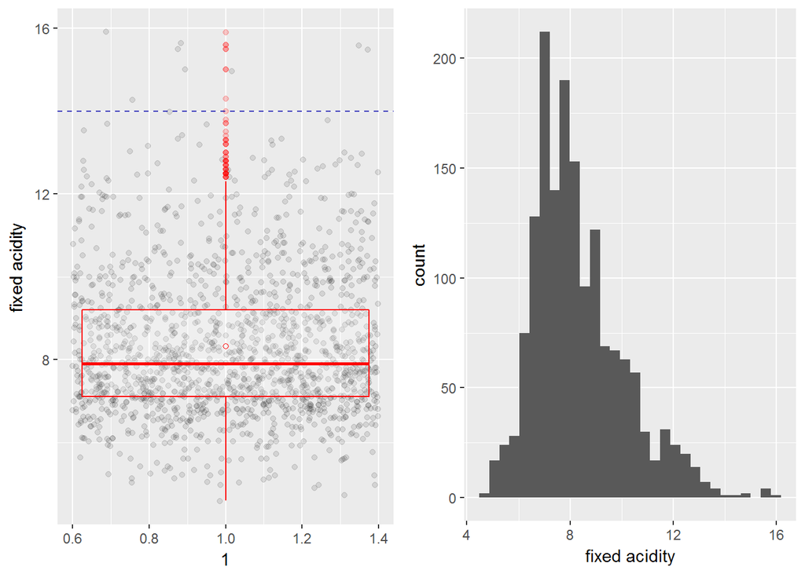

```r
box_hist_plot(redwine$fixed.acidity, 'fixed acidity')
```

```r
#box_hist_log10_plot(redwine$fixed.acidity, 'fixed acidity')
sd_and_outlier(redwine$fixed.acidity)
```

```
## [1] "standard deviation = 1.741"
## [1] "outlier are greater than:  13.994"
```

```r
stat_by_quality(redwine$fixed.acidity)
```

```
## redwine$quality: 3
##    Min. 1st Qu.  Median    Mean 3rd Qu.    Max.
##   6.700   7.150   7.500   8.360   9.875  11.600
## --------------------------------------------------------
## redwine$quality: 4
##    Min. 1st Qu.  Median    Mean 3rd Qu.    Max.
##   4.600   6.800   7.500   7.779   8.400  12.500
## --------------------------------------------------------
## redwine$quality: 5
##    Min. 1st Qu.  Median    Mean 3rd Qu.    Max.
##   5.000   7.100   7.800   8.167   8.900  15.900
## --------------------------------------------------------
## redwine$quality: 6
##    Min. 1st Qu.  Median    Mean 3rd Qu.    Max.
##   4.700   7.000   7.900   8.347   9.400  14.300
## --------------------------------------------------------
## redwine$quality: 7
##    Min. 1st Qu.  Median    Mean 3rd Qu.    Max.
##   4.900   7.400   8.800   8.872  10.100  15.600
## --------------------------------------------------------
## redwine$quality: 8
##    Min. 1st Qu.  Median    Mean 3rd Qu.    Max.
##   5.000   7.250   8.250   8.567  10.225  12.600
```

### 2) volatile.acidity

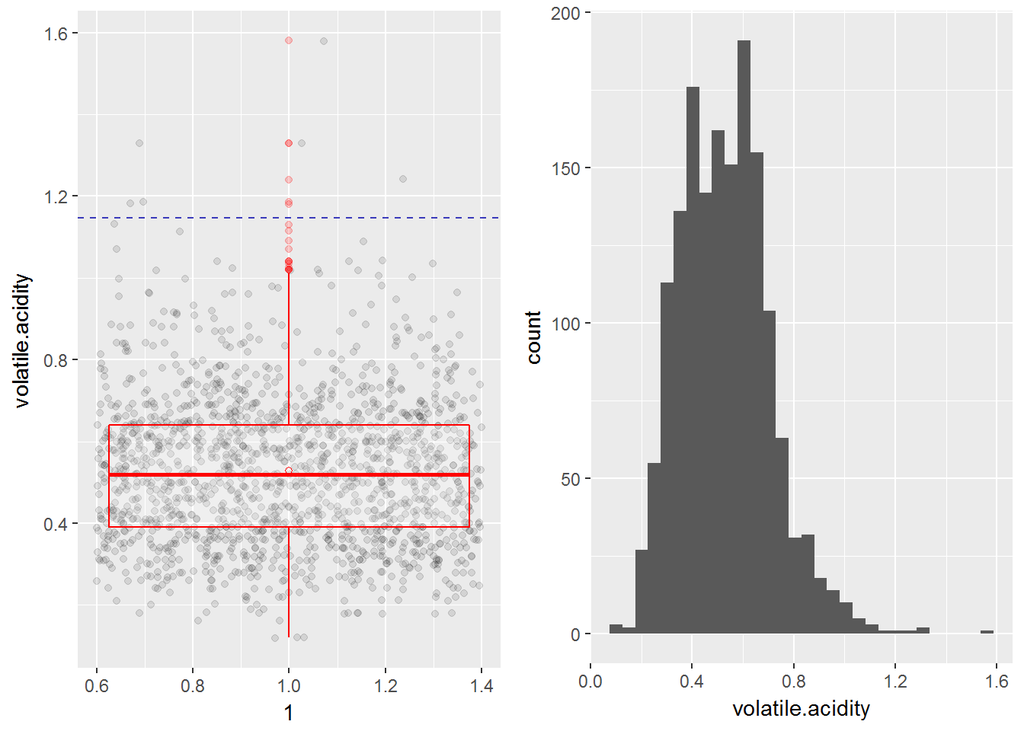

```r
box_hist_plot(redwine$volatile.acidity, "volatile.acidity")
```

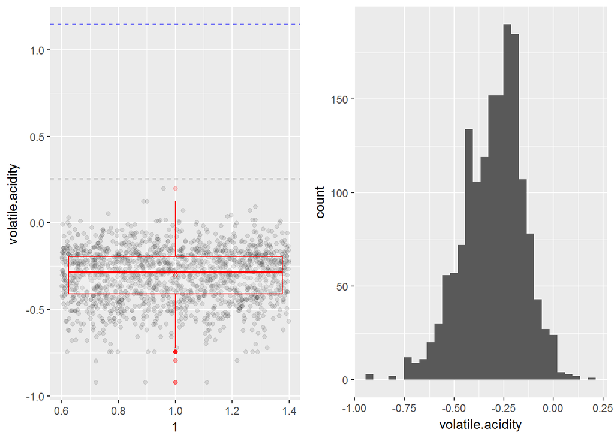

```r
box_hist_log10_plot(redwine$volatile.acidity, "volatile.acidity")
```

```r
sd_and_outlier(redwine$volatile.acidity)
```

```
## [1] "standard deviation = 0.179"
## [1] "outlier are greater than:  1.147"
```

```r
stat_by_quality(redwine$volatile.acidity)
```

```
## redwine$quality: 3
##    Min. 1st Qu.  Median    Mean 3rd Qu.    Max.
##  0.4400  0.6475  0.8450  0.8845  1.0100  1.5800
## --------------------------------------------------------
## redwine$quality: 4
##    Min. 1st Qu.  Median    Mean 3rd Qu.    Max.
##   0.230   0.530   0.670   0.694   0.870   1.130
## --------------------------------------------------------
## redwine$quality: 5
##    Min. 1st Qu.  Median    Mean 3rd Qu.    Max.
##   0.180   0.460   0.580   0.577   0.670   1.330
## --------------------------------------------------------
## redwine$quality: 6
##    Min. 1st Qu.  Median    Mean 3rd Qu.    Max.
##  0.1600  0.3800  0.4900  0.4975  0.6000  1.0400
## --------------------------------------------------------
## redwine$quality: 7
##    Min. 1st Qu.  Median    Mean 3rd Qu.    Max.
##  0.1200  0.3000  0.3700  0.4039  0.4850  0.9150
## --------------------------------------------------------
## redwine$quality: 8
##    Min. 1st Qu.  Median    Mean 3rd Qu.    Max.
##  0.2600  0.3350  0.3700  0.4233  0.4725  0.8500
```

Like fixed.acidity, volatile.acidity also shows a long tailed distribution skewed to the right. The box reveals few outliers. Applying the log10 transformation, the distribution appears to be quite normal with slightly skewed to the left. From the stat summary of volatile.acidity by quality, I noticed the mean and median volatile acidity levels are higher for the cheaper quality wines and for the higher grades this is compartively lower. From what it looks like now, this should be considered significant in deciding wine quality

### 3)citric.acid

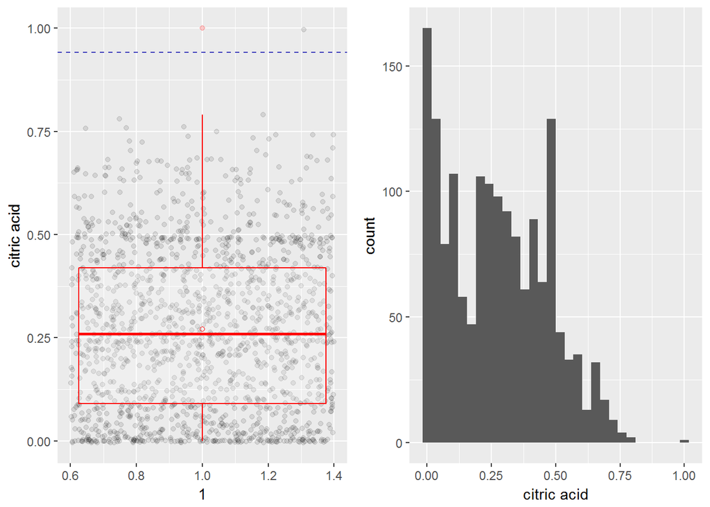

```r
box_hist_plot(redwine$citric.acid, 'citric acid')
```

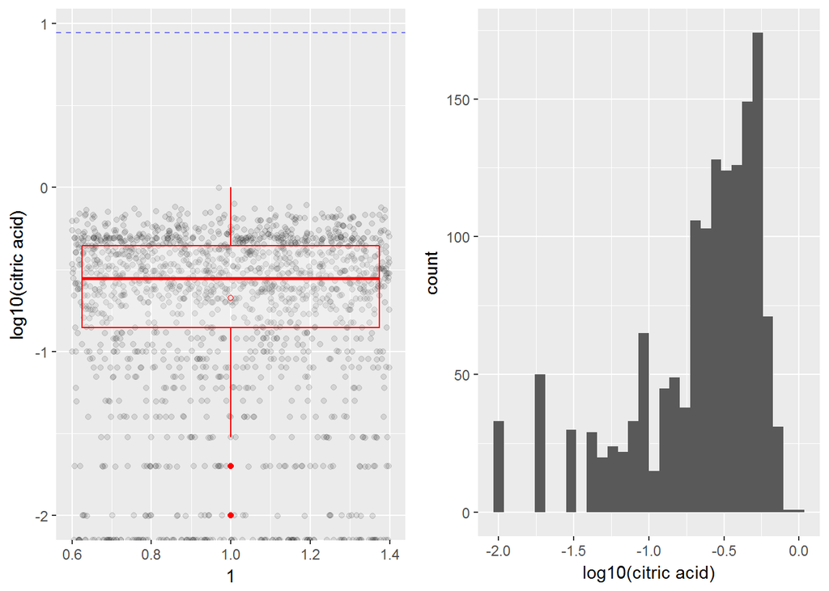

```r
box_hist_log10_plot(redwine$citric.acid, 'log10(citric acid)')
```

```r
sd_and_outlier(redwine$citric.acid)
```

```
## [1] "standard deviation = 0.195"
## [1] "outlier are greater than:  0.942"
```

```r
stat_by_quality(redwine$citric.acid)
```

```
## redwine$quality: 3
##    Min. 1st Qu.  Median    Mean 3rd Qu.    Max.
##  0.0000  0.0050  0.0350  0.1710  0.3275  0.6600
## --------------------------------------------------------
## redwine$quality: 4
##    Min. 1st Qu.  Median    Mean 3rd Qu.    Max.
##  0.0000  0.0300  0.0900  0.1742  0.2700  1.0000
## --------------------------------------------------------
## redwine$quality: 5
##    Min. 1st Qu.  Median    Mean 3rd Qu.    Max.
##  0.0000  0.0900  0.2300  0.2437  0.3600  0.7900
## --------------------------------------------------------
## redwine$quality: 6
##    Min. 1st Qu.  Median    Mean 3rd Qu.    Max.
##  0.0000  0.0900  0.2600  0.2738  0.4300  0.7800
## --------------------------------------------------------
## redwine$quality: 7
##    Min. 1st Qu.  Median    Mean 3rd Qu.    Max.
##  0.0000  0.3050  0.4000  0.3752  0.4900  0.7600
## --------------------------------------------------------
## redwine$quality: 8
##    Min. 1st Qu.  Median    Mean 3rd Qu.    Max.
##  0.0300  0.3025  0.4200  0.3911  0.5300  0.7200
```

Distribution appears to be bi-modal in the first plot. With the transformation applied in the second plot, the distribution appears to have got skewed to the left. From the stats plot, it appears that high quality wines are associated with higher values of citric acid levels. But this may need to be checked in our bi-variate plots. From the box plot, it looks like more than 75% of our sample have citric acid levels below 0.5.

### 4) residual.sugar

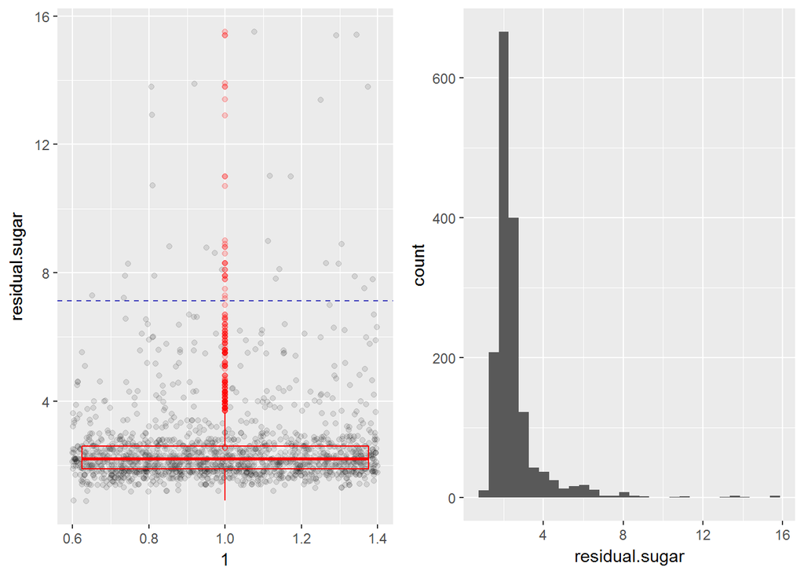

```r
box_hist_plot(redwine$residual.sugar, 'residual.sugar')
```

```r
#box_hist_log10_plot(redwine$residual.sugar, 'log10(residual.sugar)')
sd_and_outlier(redwine$residual.sugar)
```

```
## [1] "standard deviation = 1.41"
## [1] "outlier are greater than:  7.135"
```

```r
stat_by_quality(redwine$residual.sugar)
```

```
## redwine$quality: 3
##    Min. 1st Qu.  Median    Mean 3rd Qu.    Max.
##   1.200   1.875   2.100   2.635   3.100   5.700
## --------------------------------------------------------
## redwine$quality: 4
##    Min. 1st Qu.  Median    Mean 3rd Qu.    Max.
##   1.300   1.900   2.100   2.694   2.800  12.900
## --------------------------------------------------------
## redwine$quality: 5
##    Min. 1st Qu.  Median    Mean 3rd Qu.    Max.
##   1.200   1.900   2.200   2.529   2.600  15.500
## --------------------------------------------------------
## redwine$quality: 6
##    Min. 1st Qu.  Median    Mean 3rd Qu.    Max.
##   0.900   1.900   2.200   2.477   2.500  15.400
## --------------------------------------------------------
## redwine$quality: 7
##    Min. 1st Qu.  Median    Mean 3rd Qu.    Max.
##   1.200   2.000   2.300   2.721   2.750   8.900
## --------------------------------------------------------
## redwine$quality: 8
##    Min. 1st Qu.  Median    Mean 3rd Qu.    Max.
##   1.400   1.800   2.100   2.578   2.600   6.400
```

### 5) chlorides

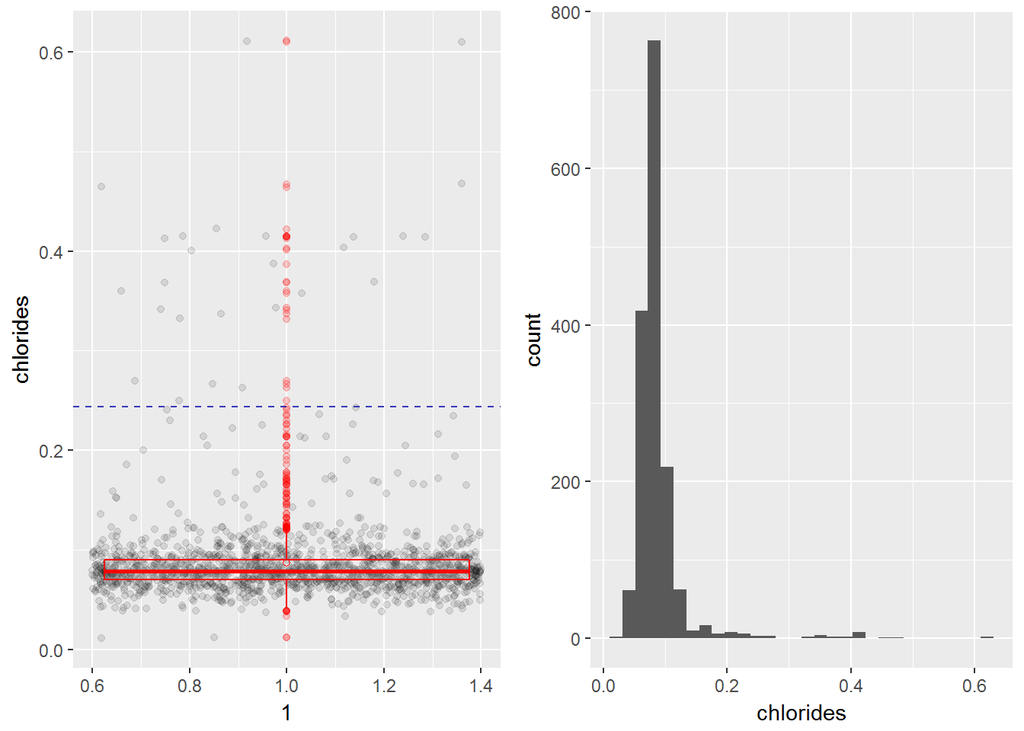

```r
box_hist_plot(redwine$chlorides, 'chlorides')
```

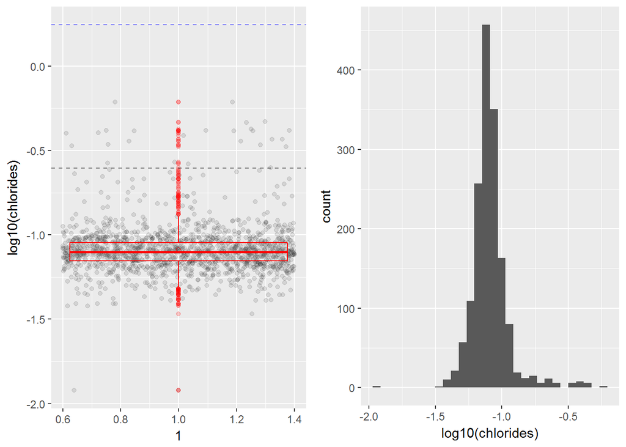

```r
box_hist_log10_plot(redwine$chlorides, 'log10(chlorides)')
```

```r
sd_and_outlier(redwine$chlorides)
```

```
## [1] "standard deviation = 0.047"
## [1] "outlier are greater than:  0.244"
```

```r
stat_by_quality(redwine$chlorides)
```

```
## redwine$quality: 3
##    Min. 1st Qu.  Median    Mean 3rd Qu.    Max.
##  0.0610  0.0790  0.0905  0.1225  0.1430  0.2670
## --------------------------------------------------------
## redwine$quality: 4
##    Min. 1st Qu.  Median    Mean 3rd Qu.    Max.
## 0.04500 0.06700 0.08000 0.09068 0.08900 0.61000
## --------------------------------------------------------
## redwine$quality: 5
##    Min. 1st Qu.  Median    Mean 3rd Qu.    Max.
## 0.03900 0.07400 0.08100 0.09274 0.09400 0.61100
## --------------------------------------------------------
## redwine$quality: 6
##    Min. 1st Qu.  Median    Mean 3rd Qu.    Max.
## 0.03400 0.06825 0.07800 0.08496 0.08800 0.41500
## --------------------------------------------------------
## redwine$quality: 7
##    Min. 1st Qu.  Median    Mean 3rd Qu.    Max.
## 0.01200 0.06200 0.07300 0.07659 0.08700 0.35800
## --------------------------------------------------------
## redwine$quality: 8
##    Min. 1st Qu.  Median    Mean 3rd Qu.    Max.
## 0.04400 0.06200 0.07050 0.06844 0.07550 0.08600
```

### 6) free.sulfur.dioxide

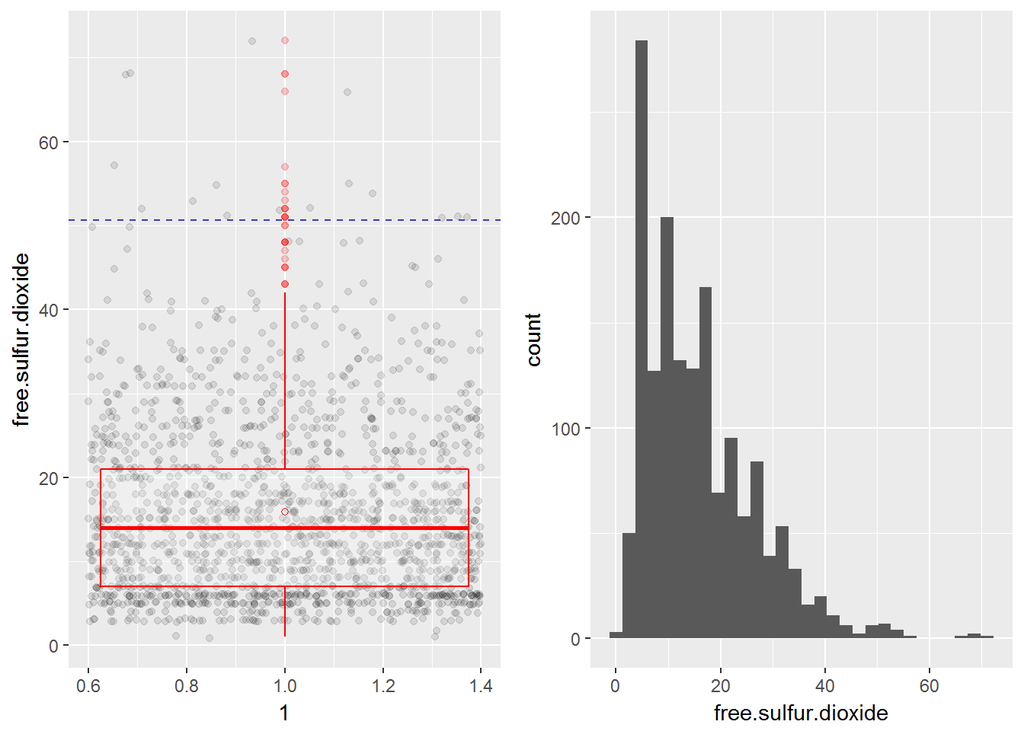

```r
box_hist_plot(redwine$free.sulfur.dioxide, 'free.sulfur.dioxide')
```

```r
#box_hist_log10_plot(redwine$free.sulfur.dioxide, 'log10(free.sulfur.dioxide)')
sd_and_outlier(redwine$free.sulfur.dioxide)
```

```
## [1] "standard deviation = 10.46"
## [1] "outlier are greater than:  50.611"
```

```r
stat_by_quality(redwine$free.sulfur.dioxide)
```

```
## redwine$quality: 3
##    Min. 1st Qu.  Median    Mean 3rd Qu.    Max.
##     3.0     5.0     6.0    11.0    14.5    34.0
## --------------------------------------------------------
## redwine$quality: 4
##    Min. 1st Qu.  Median    Mean 3rd Qu.    Max.
##    3.00    6.00   11.00   12.26   15.00   41.00
## --------------------------------------------------------
## redwine$quality: 5
##    Min. 1st Qu.  Median    Mean 3rd Qu.    Max.
##    3.00    9.00   15.00   16.98   23.00   68.00
## --------------------------------------------------------
## redwine$quality: 6
##    Min. 1st Qu.  Median    Mean 3rd Qu.    Max.
##    1.00    8.00   14.00   15.71   21.00   72.00
## --------------------------------------------------------
## redwine$quality: 7
##    Min. 1st Qu.  Median    Mean 3rd Qu.    Max.
##    3.00    6.00   11.00   14.05   18.00   54.00
## --------------------------------------------------------
## redwine$quality: 8
##    Min. 1st Qu.  Median    Mean 3rd Qu.    Max.
##    3.00    6.00    7.50   13.28   16.50   42.00
```

### 7) “total.sulfur.dioxide”

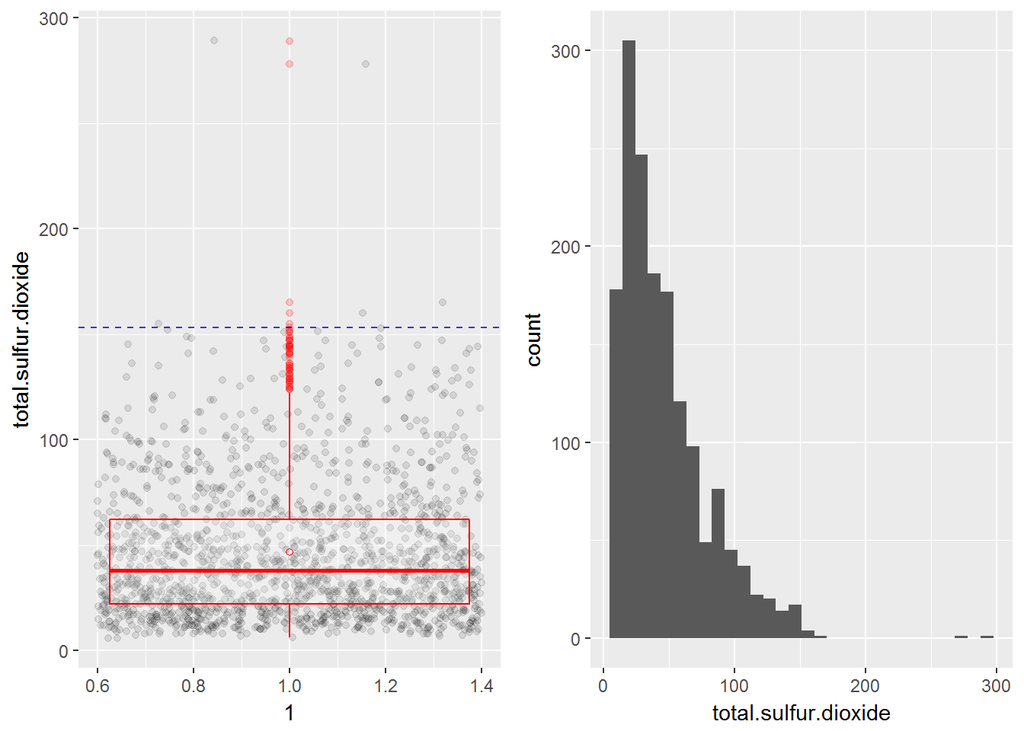

```r
box_hist_plot(redwine$total.sulfur.dioxide, 'total.sulfur.dioxide')
```

```r
#box_hist_log10_plot(redwine$total.sulfur.dioxide, 'log10(total.sulfur.dioxide)')
sd_and_outlier(redwine$total.sulfur.dioxide)
```

```
## [1] "standard deviation = 32.895"
## [1] "outlier are greater than:  153.134"
```

```r
stat_by_quality(redwine$total.sulfur.dioxide)
```

```
## redwine$quality: 3
##    Min. 1st Qu.  Median    Mean 3rd Qu.    Max.
##     9.0    12.5    15.0    24.9    42.5    49.0
## --------------------------------------------------------
## redwine$quality: 4
##    Min. 1st Qu.  Median    Mean 3rd Qu.    Max.
##    7.00   14.00   26.00   36.25   49.00  119.00
## --------------------------------------------------------
## redwine$quality: 5
##    Min. 1st Qu.  Median    Mean 3rd Qu.    Max.
##    6.00   26.00   47.00   56.51   84.00  155.00
## --------------------------------------------------------
## redwine$quality: 6
##    Min. 1st Qu.  Median    Mean 3rd Qu.    Max.
##    6.00   23.00   35.00   40.87   54.00  165.00
## --------------------------------------------------------
## redwine$quality: 7
##    Min. 1st Qu.  Median    Mean 3rd Qu.    Max.
##    7.00   17.50   27.00   35.02   43.00  289.00
## --------------------------------------------------------
## redwine$quality: 8
##    Min. 1st Qu.  Median    Mean 3rd Qu.    Max.
##   12.00   16.00   21.50   33.44   43.00   88.00
```

### 8) “density”

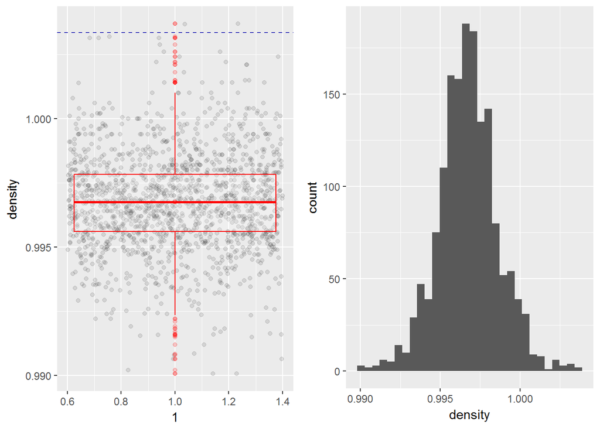

```r
box_hist_plot(redwine$density, 'density')
```

```r
#box_hist_log10_plot(redwine$density, 'log10(density)')
sd_and_outlier(redwine$density)
```

```
## [1] "standard deviation = 0.002"
## [1] "outlier are greater than:  1.003"
```

```r
stat_by_quality(redwine$density)
```

```
## redwine$quality: 3
##    Min. 1st Qu.  Median    Mean 3rd Qu.    Max.
##  0.9947  0.9961  0.9976  0.9975  0.9988  1.0008
## --------------------------------------------------------
## redwine$quality: 4
##    Min. 1st Qu.  Median    Mean 3rd Qu.    Max.
##  0.9934  0.9957  0.9965  0.9965  0.9974  1.0010
## --------------------------------------------------------
## redwine$quality: 5
##    Min. 1st Qu.  Median    Mean 3rd Qu.    Max.
##  0.9926  0.9962  0.9970  0.9971  0.9979  1.0031
## --------------------------------------------------------
## redwine$quality: 6
##    Min. 1st Qu.  Median    Mean 3rd Qu.    Max.
##  0.9901  0.9954  0.9966  0.9966  0.9979  1.0037
## --------------------------------------------------------
## redwine$quality: 7
##    Min. 1st Qu.  Median    Mean 3rd Qu.    Max.
##  0.9906  0.9948  0.9958  0.9961  0.9974  1.0032
## --------------------------------------------------------
## redwine$quality: 8
##    Min. 1st Qu.  Median    Mean 3rd Qu.    Max.
##  0.9908  0.9942  0.9949  0.9952  0.9972  0.9988
```

### 9) “pH”

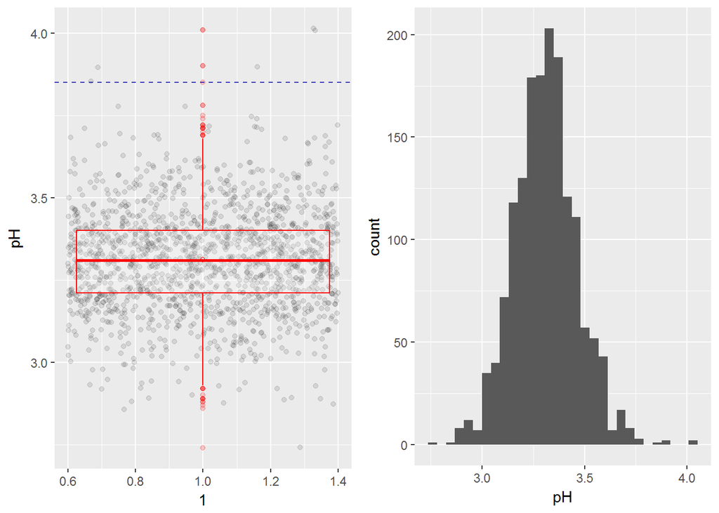

```r
box_hist_plot(redwine$pH, 'pH')
```

```r
#box_hist_log10_plot(redwine$pH, 'log10(pH)')
sd_and_outlier(redwine$pH)
```

```
## [1] "standard deviation = 0.154"
## [1] "outlier are greater than:  3.85"
```

```r
stat_by_quality(redwine$pH)
```

```
## redwine$quality: 3
##    Min. 1st Qu.  Median    Mean 3rd Qu.    Max.
##   3.160   3.312   3.390   3.398   3.495   3.630
## --------------------------------------------------------
## redwine$quality: 4
##    Min. 1st Qu.  Median    Mean 3rd Qu.    Max.
##   2.740   3.300   3.370   3.382   3.500   3.900
## --------------------------------------------------------
## redwine$quality: 5
##    Min. 1st Qu.  Median    Mean 3rd Qu.    Max.
##   2.880   3.200   3.300   3.305   3.400   3.740
## --------------------------------------------------------
## redwine$quality: 6
##    Min. 1st Qu.  Median    Mean 3rd Qu.    Max.
##   2.860   3.220   3.320   3.318   3.410   4.010
## --------------------------------------------------------
## redwine$quality: 7
##    Min. 1st Qu.  Median    Mean 3rd Qu.    Max.
##   2.920   3.200   3.280   3.291   3.380   3.780
## --------------------------------------------------------
## redwine$quality: 8
##    Min. 1st Qu.  Median    Mean 3rd Qu.    Max.
##   2.880   3.163   3.230   3.267   3.350   3.720
```

Most of the wines have a pH between 3 and 3.5 and we can see a normal distribution for the histogram. From stats summary, based on the mean and median, most of the wine samples have PH values around 3.2 to 3.5 and there is not much of a dispersion with repsect to pH values between different grades of wines.

### 10) “sulphates”

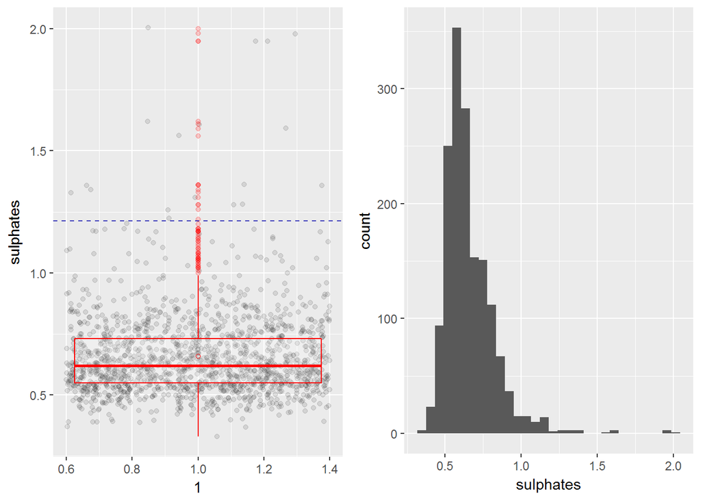

```r
box_hist_plot(redwine$sulphates, 'sulphates')
```

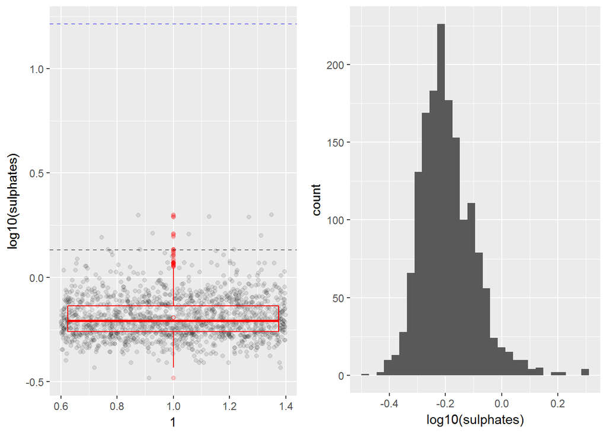

```r
box_hist_log10_plot(redwine$sulphates, 'log10(sulphates)')
```

```r
sd_and_outlier(redwine$sulphates)
```

```
## [1] "standard deviation = 0.17"
## [1] "outlier are greater than:  1.213"
```

```r
stat_by_quality(redwine$sulphates)
```

```
## redwine$quality: 3
##    Min. 1st Qu.  Median    Mean 3rd Qu.    Max.
##  0.4000  0.5125  0.5450  0.5700  0.6150  0.8600
## --------------------------------------------------------
## redwine$quality: 4
##    Min. 1st Qu.  Median    Mean 3rd Qu.    Max.
##  0.3300  0.4900  0.5600  0.5964  0.6000  2.0000
## --------------------------------------------------------
## redwine$quality: 5
##    Min. 1st Qu.  Median    Mean 3rd Qu.    Max.
##   0.370   0.530   0.580   0.621   0.660   1.980
## --------------------------------------------------------
## redwine$quality: 6
##    Min. 1st Qu.  Median    Mean 3rd Qu.    Max.
##  0.4000  0.5800  0.6400  0.6753  0.7500  1.9500
## --------------------------------------------------------
## redwine$quality: 7
##    Min. 1st Qu.  Median    Mean 3rd Qu.    Max.
##  0.3900  0.6500  0.7400  0.7413  0.8300  1.3600
## --------------------------------------------------------
## redwine$quality: 8
##    Min. 1st Qu.  Median    Mean 3rd Qu.    Max.
##  0.6300  0.6900  0.7400  0.7678  0.8200  1.1000
```

Distribution is skewed to the right.With log transformation, the distribution is more normal.Observed higher mean and medan sulphate content for the higher grade wines.

### 11) alcohol

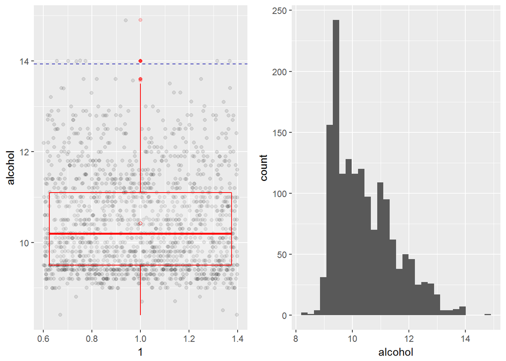

```r
box_hist_plot(redwine$alcohol, 'alcohol')
```

```r
#box_hist_log10_plot(redwine$alcohol, 'log10(alcohol)')
sd_and_outlier(redwine$alcohol)
```

```
## [1] "standard deviation = 1.066"
## [1] "outlier are greater than:  13.93"
```

```r
stat_by_quality(redwine$alcohol)
```

```
## redwine$quality: 3
##    Min. 1st Qu.  Median    Mean 3rd Qu.    Max.
##   8.400   9.725   9.925   9.955  10.575  11.000
## --------------------------------------------------------
## redwine$quality: 4
##    Min. 1st Qu.  Median    Mean 3rd Qu.    Max.
##    9.00    9.60   10.00   10.27   11.00   13.10
## --------------------------------------------------------
## redwine$quality: 5
##    Min. 1st Qu.  Median    Mean 3rd Qu.    Max.
##     8.5     9.4     9.7     9.9    10.2    14.9
## --------------------------------------------------------
## redwine$quality: 6
##    Min. 1st Qu.  Median    Mean 3rd Qu.    Max.
##    8.40    9.80   10.50   10.63   11.30   14.00
## --------------------------------------------------------
## redwine$quality: 7
##    Min. 1st Qu.  Median    Mean 3rd Qu.    Max.
##    9.20   10.80   11.50   11.47   12.10   14.00
## --------------------------------------------------------
## redwine$quality: 8
##    Min. 1st Qu.  Median    Mean 3rd Qu.    Max.
##    9.80   11.32   12.15   12.09   12.88   14.00
```

### 12) quality

#### barplot

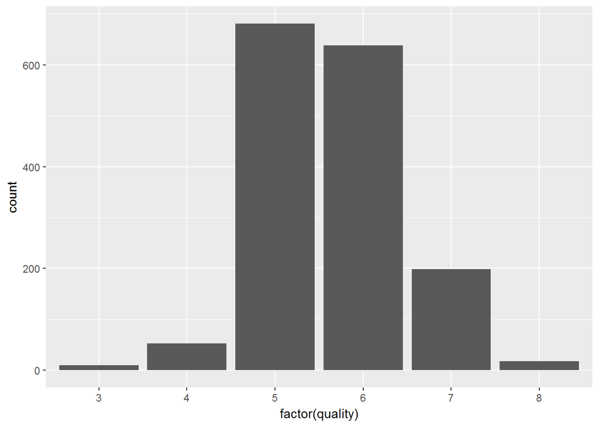

From the plots, I see most of the wines are of quality 5 and 6. There are less samples for the higher grade wines 7 and 8. Most of the wines in our sample are of average grade.

#### Summary of red wine quality

#### Number of wine samples of each grade is as below

```r
summary(redwine$quality)
```

```
##    Min. 1st Qu.  Median    Mean 3rd Qu.    Max.
##   3.000   5.000   6.000   5.636   6.000   8.000
```

```r
table(redwine$quality)
```

```
##
##   3   4   5   6   7   8
##  10  53 681 638 199  18
```

## creating new variables - total acidity and used.sulfur.dioxide

### 13) create a new variable total.acidity = fixed.acidity + volatile.acidity

```r
redwine$total.acidity <- redwine$fixed.acidity + redwine$volatile.acidity
```

#### plots

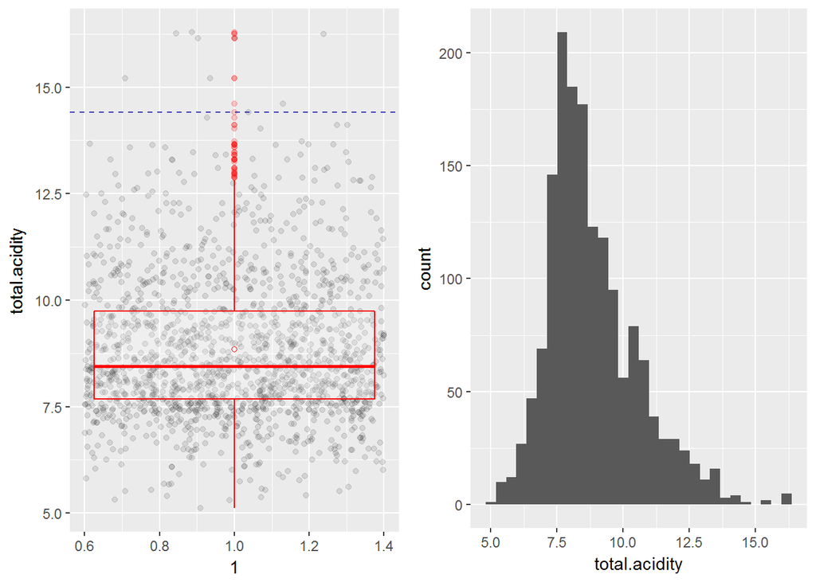

```r
box_hist_plot(redwine$total.acidity, 'total.acidity')
```

```r
#box_hist_log10_plot(redwine$total.acidity, 'log10(total.acidity)')
sd_and_outlier(redwine$total.acidity)
```

```
## [1] "standard deviation = 1.704"
## [1] "outlier are greater than:  14.409"
```

```r
stat_by_quality(redwine$total.acidity)
```

```
## redwine$quality: 3
##    Min. 1st Qu.  Median    Mean 3rd Qu.    Max.
##   7.460   8.051   8.883   9.245  10.460  12.180
## --------------------------------------------------------
## redwine$quality: 4
##    Min. 1st Qu.  Median    Mean 3rd Qu.    Max.
##   5.120   7.380   8.185   8.473   9.070  12.960
## --------------------------------------------------------
## redwine$quality: 5
##    Min. 1st Qu.  Median    Mean 3rd Qu.    Max.
##   5.520   7.735   8.390   8.744   9.490  16.260
## --------------------------------------------------------
## redwine$quality: 6
##    Min. 1st Qu.  Median    Mean 3rd Qu.    Max.
##   5.300   7.605   8.400   8.845   9.881  14.610
## --------------------------------------------------------
## redwine$quality: 7
##    Min. 1st Qu.  Median    Mean 3rd Qu.    Max.
##   5.320   7.880   9.110   9.276  10.485  16.285
## --------------------------------------------------------
## redwine$quality: 8
##    Min. 1st Qu.  Median    Mean 3rd Qu.    Max.
##   5.420   7.625   8.730   8.990  10.530  12.910
```

The distribution follows similar to that of fixed.acidity and volatile.acidity

### 14) create a second new variable - used.sulfur.dioxide which is total.sulfur.dioxide - free.sulfur.dioxide

```r
redwine$used.sulfur.dioxide <- redwine$total.sulfur.dioxide - redwine$free.sulfur.dioxide
```

#### plots

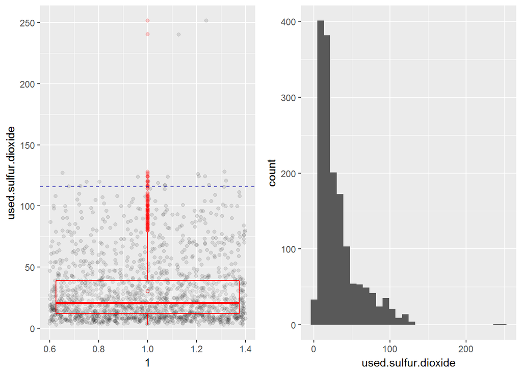

```r
box_hist_plot(redwine$used.sulfur.dioxide, 'used.sulfur.dioxide')
```

```r
#box_hist_log10_plot(redwine$used.sulfur.dioxide, 'log10(used.sulfur.dioxide)')
sd_and_outlier(redwine$used.sulfur.dioxide)
```

```
## [1] "standard deviation = 27.056"
## [1] "outlier are greater than:  115.697"
```

```r
stat_by_quality(redwine$used.sulfur.dioxide)
```

```
## redwine$quality: 3
##    Min. 1st Qu.  Median    Mean 3rd Qu.    Max.
##    4.00    6.75   11.00   13.90   13.75   37.00
## --------------------------------------------------------
## redwine$quality: 4
##    Min. 1st Qu.  Median    Mean 3rd Qu.    Max.
##    3.00    8.00   14.00   23.98   32.00  107.00
## --------------------------------------------------------
## redwine$quality: 5
##    Min. 1st Qu.  Median    Mean 3rd Qu.    Max.
##    3.00   14.00   29.00   39.53   58.00  128.00
## --------------------------------------------------------
## redwine$quality: 6
##    Min. 1st Qu.  Median    Mean 3rd Qu.    Max.
##    3.00   11.00   19.00   25.16   33.00  126.00
## --------------------------------------------------------
## redwine$quality: 7
##    Min. 1st Qu.  Median    Mean 3rd Qu.    Max.
##    4.00    8.50   15.00   20.97   21.50  251.50
## --------------------------------------------------------
## redwine$quality: 8
##    Min. 1st Qu.  Median    Mean 3rd Qu.    Max.
##    6.00    9.25   11.00   20.17   22.75   76.00
```

### Univariate Analysis

### What is the structure of your dataset?

#### Number of samples of each wine grade

```r
table(redwine$quality)
```

```
##
##   3   4   5   6   7   8
##  10  53 681 638 199  18
```

##### Distribution is skewed to the right for normal histogram plots for alcohol, suplhates, sulphur dioxide, residual sugar

##### more than 75% of our sample have citric acid levels below 0.5

##### Most of the wines have a denisty of 0.99XX

##### The most normal distribution is observered for pH and density.

### What is/are the main feature(s) of interest in your dataset?

#### (Ans)THe main feature will be quality and I would like to find how correlated are the other variables w.r.t quality

### What other features in the dataset do you think will help support your investigation into your feature(s) of interest?

#### (Ans) I expect alcohol, residual sugar, pH and acidity levels to be significant in deciding the wine quality

### Did you create any new variables from existing variables in the dataset?

#### (Ans)Yes. I created 2 - one for the sulphur dioxide and the other for total acidity.

### Of the features you investigated, were there any unusual distributions? Did you perform any operations on the data to tidy, adjust, or change the form of the data? If so, why did you do this?

#### (Ans)Most of the wine sample are of average type i.e between 5 and 6. There are very few sample of higher quality. When the distribution appeared to be skewed, I applied log transformation to get a more normalized dsitribution. But even with this in some cases, it did not help as distributions sometime turned to be bimodal.

### Bivariate Plots Section

For the bivariate analayis, i will start by looking at the correlation between features using ggcorr(). Using features/columns from 2:15 in the data

```
## 'data.frame':    1599 obs. of  15 variables:
##  $ X                   : int  1 2 3 4 5 6 7 8 9 10 ...
##  $ fixed.acidity       : num  7.4 7.8 7.8 11.2 7.4 7.4 7.9 7.3 7.8 7.5 ...
##  $ volatile.acidity    : num  0.7 0.88 0.76 0.28 0.7 0.66 0.6 0.65 0.58 0.5 ...
##  $ citric.acid         : num  0 0 0.04 0.56 0 0 0.06 0 0.02 0.36 ...
##  $ residual.sugar      : num  1.9 2.6 2.3 1.9 1.9 1.8 1.6 1.2 2 6.1 ...
##  $ chlorides           : num  0.076 0.098 0.092 0.075 0.076 0.075 0.069 0.065 0.073 0.071 ...
##  $ free.sulfur.dioxide : num  11 25 15 17 11 13 15 15 9 17 ...
##  $ total.sulfur.dioxide: num  34 67 54 60 34 40 59 21 18 102 ...
##  $ density             : num  0.998 0.997 0.997 0.998 0.998 ...
##  $ pH                  : num  3.51 3.2 3.26 3.16 3.51 3.51 3.3 3.39 3.36 3.35 ...
##  $ sulphates           : num  0.56 0.68 0.65 0.58 0.56 0.56 0.46 0.47 0.57 0.8 ...
##  $ alcohol             : num  9.4 9.8 9.8 9.8 9.4 9.4 9.4 10 9.5 10.5 ...
##  $ quality             : int  5 5 5 6 5 5 5 7 7 5 ...
##  $ total.acidity       : num  8.1 8.68 8.56 11.48 8.1 ...
##  $ used.sulfur.dioxide : num  23 42 39 43 23 27 44 6 9 85 ...
```

```
##  [1] "X"                    "fixed.acidity"        "volatile.acidity"
##  [4] "citric.acid"          "residual.sugar"       "chlorides"
##  [7] "free.sulfur.dioxide"  "total.sulfur.dioxide" "density"
## [10] "pH"                   "sulphates"            "alcohol"
## [13] "quality"              "total.acidity"        "used.sulfur.dioxide"
```

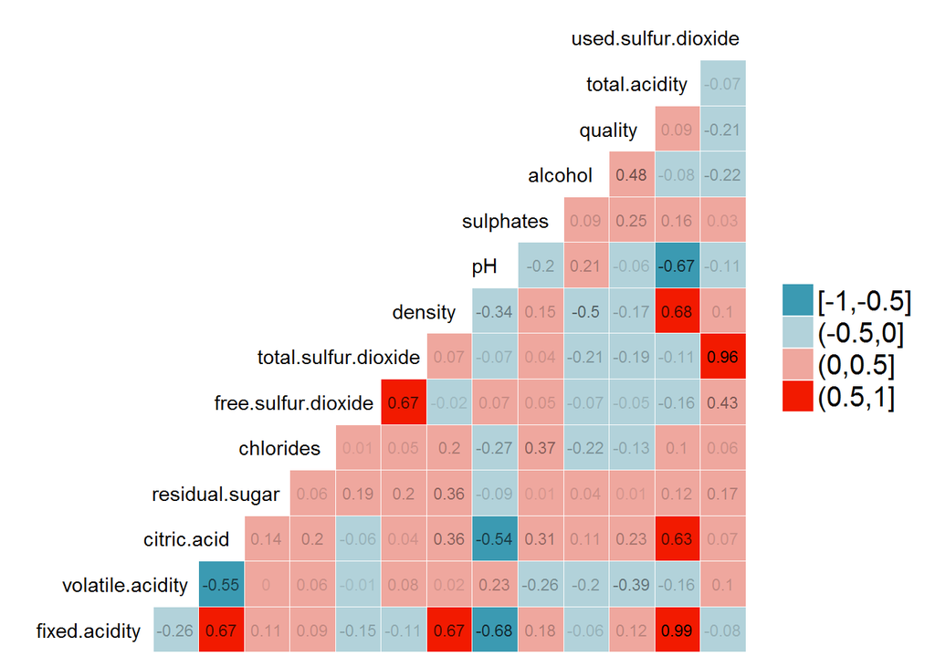

#### Analyis of the correlation plot

Get the correlation between multiple variables in text rather than the plot in ggcorr()

```r
cor(redwine)
```

```
##                                 X fixed.acidity volatile.acidity
## X                     1.000000000   -0.26848392     -0.008815099
## fixed.acidity        -0.268483920    1.00000000     -0.256130895
## volatile.acidity     -0.008815099   -0.25613089      1.000000000
## citric.acid          -0.153551355    0.67170343     -0.552495685
## residual.sugar       -0.031260835    0.11477672      0.001917882
## chlorides            -0.119868519    0.09370519      0.061297772
## free.sulfur.dioxide   0.090479643   -0.15379419     -0.010503827
## total.sulfur.dioxide -0.117849669   -0.11318144      0.076470005
## density              -0.368372087    0.66804729      0.022026232
## pH                    0.136005328   -0.68297819      0.234937294
## sulphates            -0.125306999    0.18300566     -0.260986685
## alcohol               0.245122841   -0.06166827     -0.202288027
## quality               0.066452608    0.12405165     -0.390557780
## total.acidity        -0.275247580    0.99482800     -0.156620601
## used.sulfur.dioxide  -0.178263036   -0.07814929      0.097033939
##                      citric.acid residual.sugar    chlorides
## X                    -0.15355136   -0.031260835 -0.119868519
## fixed.acidity         0.67170343    0.114776724  0.093705186
## volatile.acidity     -0.55249568    0.001917882  0.061297772
## citric.acid           1.00000000    0.143577162  0.203822914
## residual.sugar        0.14357716    1.000000000  0.055609535
## chlorides             0.20382291    0.055609535  1.000000000
## free.sulfur.dioxide  -0.06097813    0.187048995  0.005562147
## total.sulfur.dioxide  0.03553302    0.203027882  0.047400468
## density               0.36494718    0.355283371  0.200632327
## pH                   -0.54190414   -0.085652422 -0.265026131
## sulphates             0.31277004    0.005527121  0.371260481
## alcohol               0.10990325    0.042075437 -0.221140545
## quality               0.22637251    0.013731637 -0.128906560
## total.acidity         0.62825187    0.117473729  0.102183639
## used.sulfur.dioxide   0.06677604    0.174529035  0.055479649
##                      free.sulfur.dioxide total.sulfur.dioxide     density
## X                            0.090479643          -0.11784967 -0.36837209
## fixed.acidity               -0.153794193          -0.11318144  0.66804729
## volatile.acidity            -0.010503827           0.07647000  0.02202623
## citric.acid                 -0.060978129           0.03553302  0.36494718
## residual.sugar               0.187048995           0.20302788  0.35528337
## chlorides                    0.005562147           0.04740047  0.20063233
## free.sulfur.dioxide          1.000000000           0.66766645 -0.02194583
```

[output cut: 25 more lines]

```
## X                      -0.27524758         -0.17826304
## fixed.acidity           0.99482800         -0.07814929
## volatile.acidity       -0.15662060          0.09703394
## citric.acid             0.62825187          0.06677604
## residual.sugar          0.11747373          0.17452903
## chlorides               0.10218364          0.05547965
## free.sulfur.dioxide    -0.15824172          0.42514892
## total.sulfur.dioxide   -0.10760684          0.95768634
## density                 0.68488647          0.09513464
## pH                     -0.67314051         -0.10805328
## sulphates               0.15956033          0.03224404
## alcohol                -0.08426530         -0.22320257
## quality                 0.08570932         -0.20546298
## total.acidity           1.00000000         -0.06965217
## used.sulfur.dioxide    -0.06965217          1.00000000
```

I will check the all the positive correlations identified with the ggcorr() and cor() against the quality variables and plot them to understand. Similarly some of the negative correlation variables will also be explored.

#### 1) Alcohol content - positive correlation

#### plots

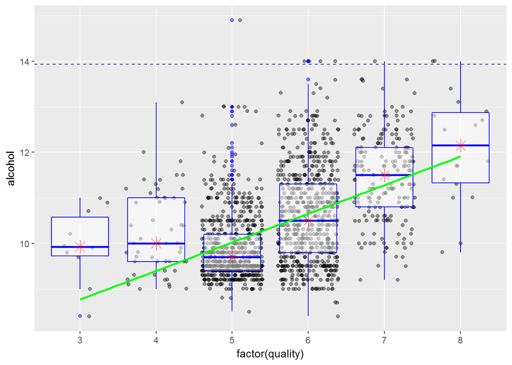

```r
box_scatter(redwine$alcohol, 'alcohol')
```

```r
#box_scatter_log10(redwine$alcohol, 'alcohol')
cor.test(redwine$alcohol, redwine$quality)
```

```
##
##  Pearson's product-moment correlation
##
## data:  redwine$alcohol and redwine$quality
## t = 21.639, df = 1597, p-value < 2.2e-16
## alternative hypothesis: true correlation is not equal to 0
## 95 percent confidence interval:
##  0.4373540 0.5132081
## sample estimates:
##       cor
## 0.4761663
```

```r
cor.test(log10(redwine$alcohol), redwine$quality)
```

```
##
##  Pearson's product-moment correlation
##
## data:  log10(redwine$alcohol) and redwine$quality
## t = 21.687, df = 1597, p-value < 2.2e-16
## alternative hypothesis: true correlation is not equal to 0
## 95 percent confidence interval:
##  0.4382062 0.5139842
## sample estimates:
##       cor
## 0.4769811
```

```r
stat_by_quality(redwine$alcohol)
```

```
## redwine$quality: 3
##    Min. 1st Qu.  Median    Mean 3rd Qu.    Max.
##   8.400   9.725   9.925   9.955  10.575  11.000
## --------------------------------------------------------
## redwine$quality: 4
##    Min. 1st Qu.  Median    Mean 3rd Qu.    Max.
##    9.00    9.60   10.00   10.27   11.00   13.10
## --------------------------------------------------------
## redwine$quality: 5
##    Min. 1st Qu.  Median    Mean 3rd Qu.    Max.
##     8.5     9.4     9.7     9.9    10.2    14.9
## --------------------------------------------------------
## redwine$quality: 6
##    Min. 1st Qu.  Median    Mean 3rd Qu.    Max.
##    8.40    9.80   10.50   10.63   11.30   14.00
## --------------------------------------------------------
## redwine$quality: 7
##    Min. 1st Qu.  Median    Mean 3rd Qu.    Max.
##    9.20   10.80   11.50   11.47   12.10   14.00
## --------------------------------------------------------
## redwine$quality: 8
##    Min. 1st Qu.  Median    Mean 3rd Qu.    Max.
##    9.80   11.32   12.15   12.09   12.88   14.00
```